# Phase 3: WHEAT Agricultural Commodity Loss Variations across the Pacific Northwest Palouse Region, 1989-2015 - Mixed Modeling Analysis

Erich Seamon

9/25/2018

## Introduction

This analysis explores the relationships of agricultural commodity loss, at a county level, from 1989-2015, for the 26 county region of the Palouse, in Washington, Idaho, and Oregon. Here we explore the entire range of commodities and damage causes, identifying the top revenue loss commodities and their most pertinent damage causes - as indicated from the USDA’s agricultural commodity loss insurance archive.

In Phase 3, we perform WHEAT mixed modeling analysis using a two-step hurdle technique for a selected set of damage causes. The following analysis builds on Phases 1 and 2, steps 1-10.

## Step 9: Hurdle Mixed Models

Hurdle model techniques allow us to address zero inflated datasets, by first running a logstical regression model to determine the probability of zeros occuring. Then we use the non-zero values in a separate, mixed model. In this instance, we use county as a random effect.

As such, these are not missing data, but actual zero values that we do not want to exclude from our model. However we want to be able to use a normalized distribution that is not positively skewed/zero inflated.

## Hurdle Model - WHEAT

Here we run our hurdle technique for WHEAT, using a generalized linear model with a binomal function to delineate between zero and non-zero values. Given this model, Is our data normally distributed? What (if any) outliers exist? Are residuals well distributed - indicating normality?

```
##           llh       llhNull            G2      McFadden          r2ML
## -1392.6347080 -1967.6122795  1149.9551430     0.2922210     0.3184041
##          r2CU
##     0.4357824
```

```
##
##  Hosmer and Lemeshow goodness of fit (GOF) test
##
## data:  alllevs2_wheat$non_zero, fitted(m1)
## X-squared = 8.0966, df = 8, p-value = 0.4241
```

**FIGURE 12:** Wheat Non-zero Goodness of fit hoslem test

Now plot this Wheat zero/non-zero bionomal model to see outliers and the zeros vs non-zeros.

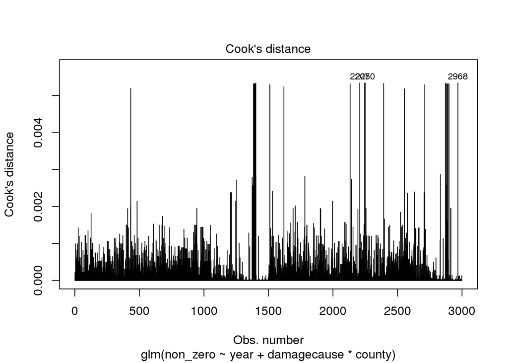

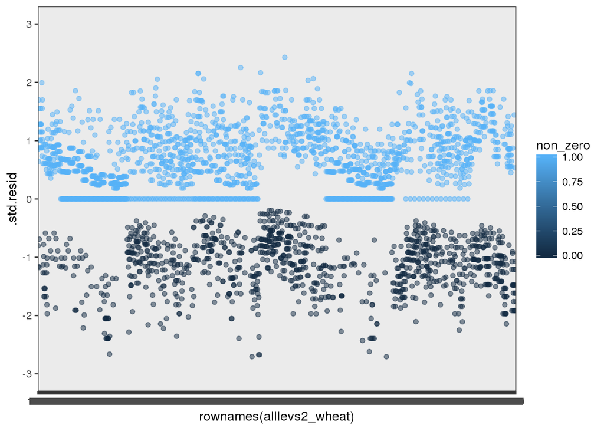

### Checking for multi collinearity

```
##                    GVIF  Df GVIF^(1/(2*Df))
## year                NaN  14             NaN
## damagecause         NaN   7             NaN
## county              NaN  24             NaN
## damagecause:county  NaN 168             NaN
```

**FIGURE 14:** Wheat multi-collinearity test for our binomal model.

```
##                                     pvalue
## year2003                      3.591447e-02
## year2006                      2.436066e-03
## year2008                      7.423814e-06
## year2009                      1.928975e-07
## year2010                      6.395700e-05
## year2012                      7.423814e-06
## year2013                      1.358972e-11
## year2014                      6.886671e-07
## year2015                      4.184055e-06
## countyAsotin                  9.075356e-03
## countyBenton                  9.075356e-03
## countyColumbia                2.261309e-02
## countyGarfield                9.075356e-03
## countyGilliam                 2.261309e-02
## countySherman                 2.261309e-02
## countyUnion                   2.261309e-02
## damagecauseHail:countyLincoln 4.935426e-02
## damagecauseHail:countyUnion   2.690240e-02
```

**FIGURE 14:** Wheat binomal model summary

## Now subset to just those WHEAT observations with a loss greater than zero (so all non-zeros), and run a linear regression (switched to log loss due to outliers), to make sure that our residuals and other parameters suggest normality.

```
## Linear mixed model fit by REML ['lmerMod']
## Formula: log(loss) ~ year + damagecause + (1 | county)
##    Data: subset(alllevs2_wheat, non_zero == 1)
##
## REML criterion at convergence: 7179.9
##
## Scaled residuals:
##     Min      1Q  Median      3Q     Max
## -3.6996 -0.5892  0.0703  0.6781  2.6628
##
## Random effects:
##  Groups   Name        Variance Std.Dev.
##  county   (Intercept) 0.3674   0.6061
##  Residual             2.4149   1.5540
## Number of obs: 1907, groups:  county, 25
##
## Fixed effects:
##                             Estimate Std. Error t value
## (Intercept)                  7.99724    0.22116   36.16
## year2002                     0.43290    0.21176    2.04
## year2003                     0.41796    0.22225    1.88
## year2004                     0.27795    0.21310    1.30
## year2005                     0.07724    0.21910    0.35
## year2006                     0.68710    0.20185    3.40
## year2007                     1.05394    0.21526    4.90
## year2008                     1.69925    0.19843    8.56
## year2009                     2.80687    0.19683   14.26
## year2010                     1.03500    0.19983    5.18
## year2011                     1.13875    0.20808    5.47
## year2012                     1.08797    0.19821    5.49
## year2013                     1.87594    0.19346    9.70
## year2014                     2.09590    0.19745   10.61
## year2015                     2.44563    0.19867   12.31
## damagecauseCold Winter      -0.20275    0.15514   -1.31
## damagecauseDecline in Price  0.25623    0.15697    1.63
## damagecauseDrought           1.95038    0.14151   13.78
## damagecauseFreeze           -0.07762    0.15223   -0.51
## damagecauseFrost             0.50660    0.15314    3.31
## damagecauseHail              0.60254    0.17121    3.52
## damagecauseHeat              1.11373    0.14213    7.84
```

**FIGURE 18:** Wheat mixed model coefficient estimates for damage cause and year.

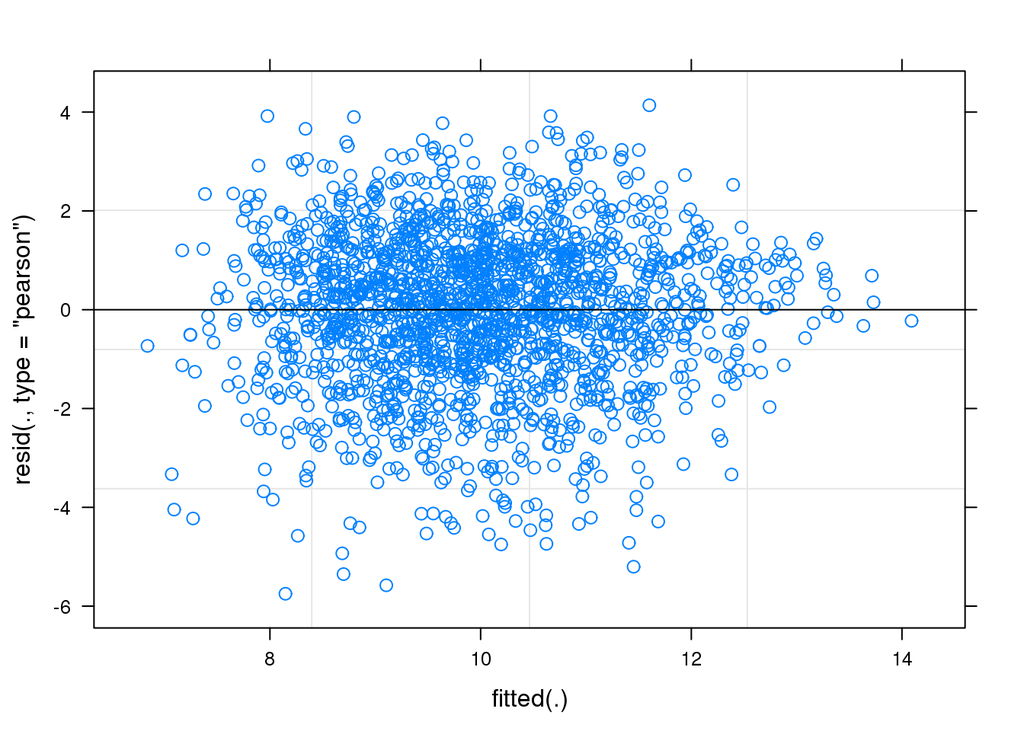

# We examine the Wheat model coefficent estimates of our model output.

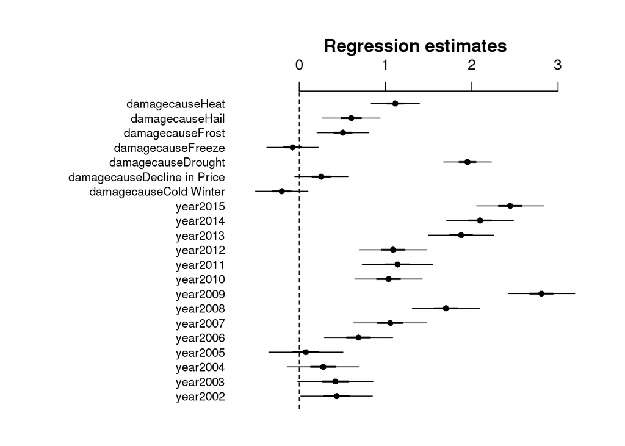

**FIGURE 19:** Wheat mixed model coefficient estimates.

# Finally, we exponentiate the coefficient estimates and confidence intervals for odds ratios.

```
##                              rn      lower     upper   estimate stderror
##  1:                    year2002  1.0199348  2.329465  1.5417217 1.235853
##  2:                    year2003  0.9846293  2.342657  1.5188577 1.248884
##  3:                    year2004  0.8715275  2.000847  1.3204231 1.237505
##  4:                    year2005  0.7046120  1.655988  1.0802969 1.244960
##  5:                    year2006  1.3410884  2.946764  1.9879437 1.223669
##  6:                    year2007  1.8851679  4.364643  2.8689339 1.240181
##  7:                    year2008  3.7132215  8.051724  5.4698321 1.219491
##  8:                    year2009 11.2766504 24.299239 16.5580431 1.217541
##  9:                    year2010  1.9063633  4.156021  2.8151147 1.221200
## 10:                    year2011  2.0809961  4.684967  3.1228698 1.231308
## 11:                    year2012  2.0161733  4.367868  2.9682470 1.219224
## 12:                    year2013  4.4739001  9.514839  6.5269495 1.213436
## 13:                    year2014  5.5310440 11.948051  8.1327549 1.218291
## 14:                    year2015  7.8275618 16.990224 11.5377976 1.219778
## 15:      damagecauseCold Winter  0.6034317  1.105113  0.8164788 1.167822
## 16: damagecauseDecline in Price  0.9516170  1.755407  1.2920471 1.169963
## 17:          damagecauseDrought  5.3360108  9.266054  7.0313553 1.152010
## 18:           damagecauseFreeze  0.6878481  1.245579  0.9253126 1.164423
## 19:            damagecauseFrost  1.2314893  2.237926  1.6596402 1.165488
## 20:             damagecauseHail  1.3083016  2.550886  1.8267442 1.186738
## 21:             damagecauseHeat  2.3086575  4.018848  3.0457065 1.152731
##                              rn      lower     upper   estimate stderror
```

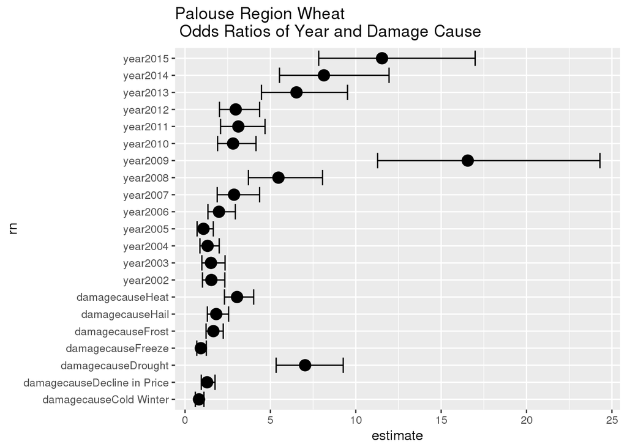

**FIGURE 20:** Wheat mixed model odds ratios.